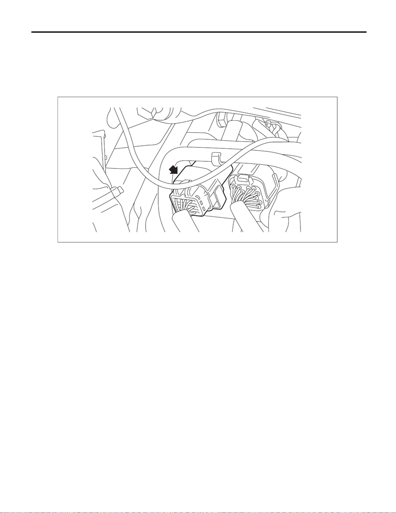

CVT(TR690)-92

Inhibitor Switch

CONTINUOUSLY VARIABLE TRANSMISSION

14.Inhibitor Switch

A: INSPECTION

When the driving condition or starter motor operation is improper, first check the shift linkage for improper op-

eration. If the shift linkage is functioning properly, check the inhibitor switch.

1) Remove the intercooler. <Ref. to IN(w/o STI)-38, REMOVAL, Intercooler.>

2) Disconnect the inhibitor harness connector.

CVT00506

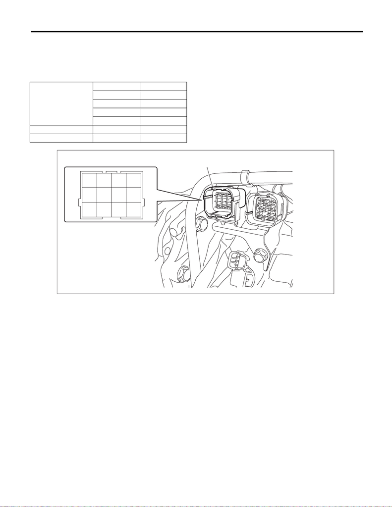

CVT(TR690)-93

Inhibitor Switch

CONTINUOUSLY VARIABLE TRANSMISSION

3) Check for continuity in inhibitor switch circuit by shifting the select lever in “P”, “R”, “N” and “D” respectively.

NOTE:

• Check that there is no continuity in the starter circuit when the select lever is in the “R” and “D” ranges.

• When inhibitor switch is normal, check there is no poor contact in vehicle side connector and no open cir-

cuit in harness.

Signal sent to TCM

Range Terminal No.

P 4 — 3

R 4 — 2

N 4 — 1

D 4 — 8

Starter circuit P/N 12 — 11

Back-up light circuit R 10 — 9

(A) Inhibitor harness connector

CVT00507

5

9

1

6

10

2

7

11

3

8

12

4

(A)

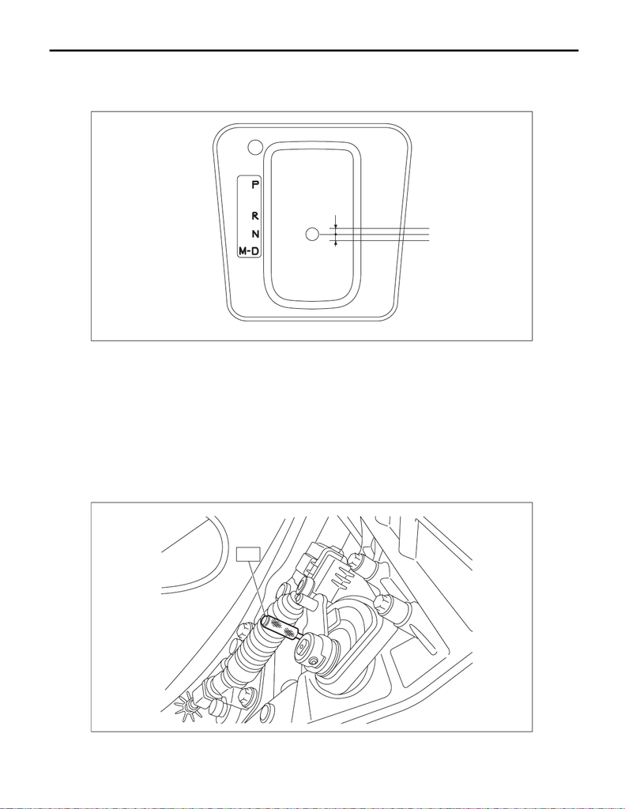

CVT(TR690)-94

Inhibitor Switch

CONTINUOUSLY VARIABLE TRANSMISSION

4) Check that there is continuity at equal points when the select lever is moved 1.5° in both directions from

the “N” range.

If there is continuity in only one direction or in other points, adjust the inhibitor switch. <Ref. to CVT(TR690)-

94, ADJUSTMENT, Inhibitor Switch.>

5) Repeat the above inspection in other gear ranges. If there is fault, adjust the inhibitor switch and select cable.

<Ref. to CVT(TR690)-94, ADJUSTMENT, Inhibitor Switch.> <Ref. to CS-47, ADJUSTMENT, Select Cable.>

B: ADJUSTMENT

1) Shift the select lever to “N” range.

2) Loosen the two bolts holding the inhibitor switch.

3) Insert the ST vertically into the holes of the shifter arm and switch body.

ST 499267300 STOPPER PIN

(A) Continuity does not exist.

(B) Continuity exists.

(C) 1.5°

AT-07839

(A)

(C)

(A)

(B)

AT-05149

ST

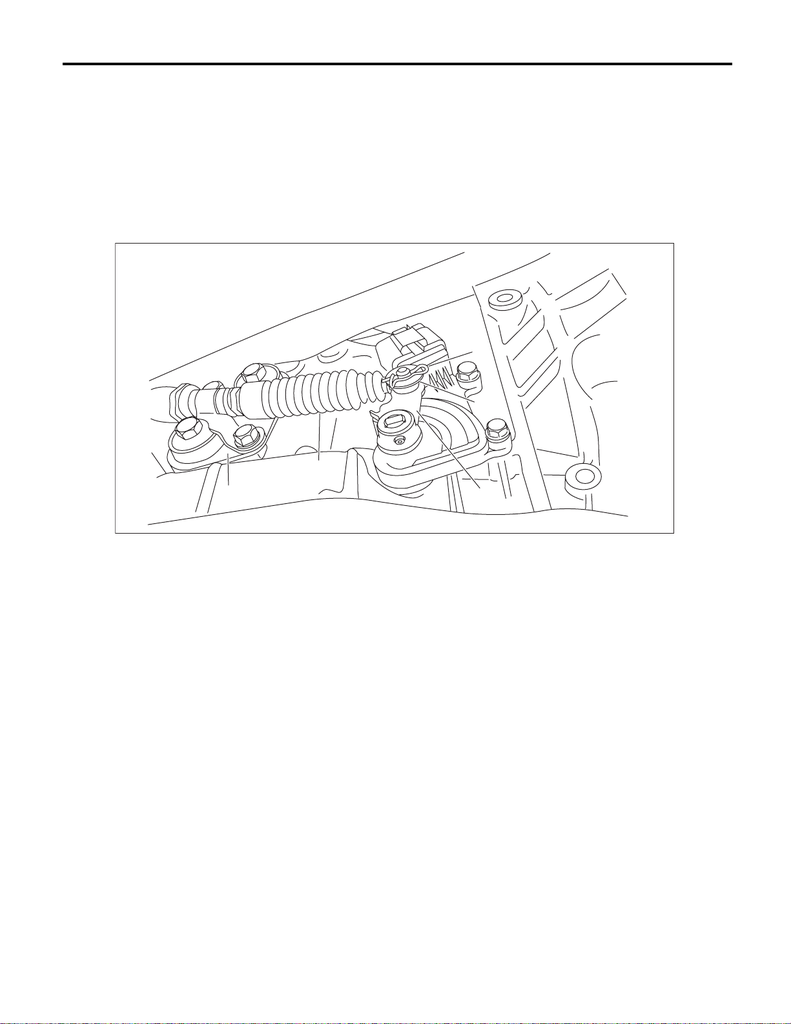

CVT(TR690)-95

Inhibitor Switch

CONTINUOUSLY VARIABLE TRANSMISSION

4) Tighten the two bolts holding the inhibitor switch.

Tightening torque:

5 N·m (0.5 kgf-m, 3.7 ft-lb)

5) Repeat the inspection of the inhibitor switch. If the inhibitor switch is determined to be “faulty”, replace it.

C: REMOVAL

1) Shift the select lever to “N” range.

2) Disconnect the ground terminal from battery sensor. <Ref. to NT-5, BATTERY, NOTE, Note.>

3) Lift up the vehicle.

4) Remove the snap pin and washer from the shifter arm.

(A) Shifter arm

(B) Snap pin

(C) Select cable

(D) Plate ASSY

(E) Washer

CS-01128

(C)

(A)

(B)

(E)

(D)

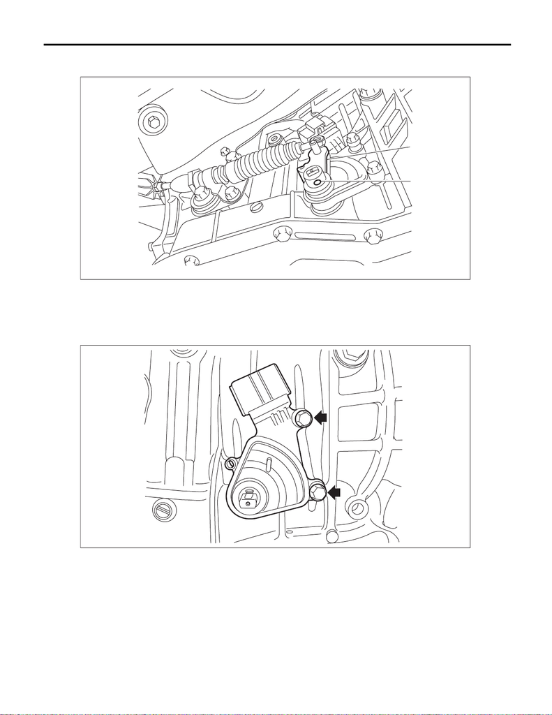

CVT(TR690)-96

Inhibitor Switch

CONTINUOUSLY VARIABLE TRANSMISSION

5) Using the ST, remove the spring pin and shifter arm.

ST 398791600 REMOVER

6) Remove the inhibitor harness connector from inhibitor switch.

7) Remove the two inhibitor switch securing bolts.

8) Remove the inhibitor switch.

(A) Spring pin

(B) Shifter arm

AT-07876

(B)

(A)

AT-05688

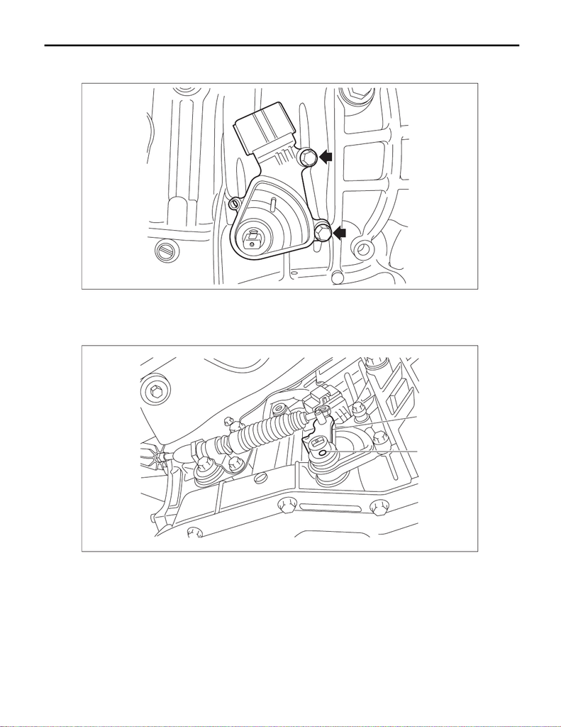

CVT(TR690)-97

Inhibitor Switch

CONTINUOUSLY VARIABLE TRANSMISSION

D: INSTALLATION

1) Temporarily install the inhibitor switch.

2) Connect the inhibitor harness connector to the inhibitor switch.

3) Install the shifter arm and fix with the spring pin.

NOTE:

Use new spring pin.

(A) Spring pin

(B) Shifter arm

AT-05688

AT-07876

(B)

(A)

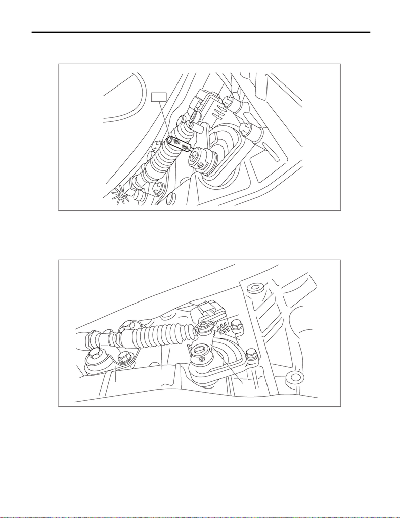

CVT(TR690)-98

Inhibitor Switch

CONTINUOUSLY VARIABLE TRANSMISSION

4) Shift the shifter arm to “N” range.

5) Install the ST vertically in the cutout of shifter arm and the hole of switch body.

ST 499267300 STOPPER PIN

6) Tighten the two bolts holding the inhibitor switch.

Tightening torque:

5 N·m (0.5 kgf-m, 3.7 ft-lb)

7) Install the select cable to the shifter arm.

8) Install the washer and snap pin to the shifter arm.

9) Lower the vehicle.

10) Connect the ground terminal to battery sensor. <Ref. to NT-5, BATTERY, NOTE, Note.>

11) Check the inhibitor switch. <Ref. to CVT(TR690)-92, INSPECTION, Inhibitor Switch.>

(A) Shifter arm

(B) Snap pin

(C) Select cable

(D) Plate ASSY

(E) Washer

AT-05149

ST

CS-01128

(C)

(A)

(B)

(E)

(D)